# 📌 Testes Não Paramétricos para Medianas e Proporções

## ⚖️ Introdução

- Testes não paramétricos são usados quando:
- Os dados não seguem distribuição normal (falha em testes como Shapiro-Wilk).
- São ordinais (ex.: escala de dor) ou nominais (ex.: grupos sanguíneos).
- Contêm outliers que distorcem análises paramétricas.

## 🔍 Parte 1: Testes Não Paramétricos para Medianas

### 📌 Teste de Mann-Whitney (U)

- Quando usar? Alternativa ao teste t para amostras independentes quando os dados não são normais.
- Compara duas medianas de grupos não relacionados.
- Exemplo em Saúde: Comparar a eficácia de dois analgésicos (A vs. B) em escalas de dor (0-10).

```python
from scipy.stats import mannwhitneyu

grupo_A = [3, 5, 2, 6, 4]  # Analgésico A
grupo_B = [7, 8, 6, 9, 7]  # Analgésico B

stat, p = mannwhitneyu(grupo_A, grupo_B)
print(f"p-valor = {p:.4f}")  # p ≤ 0.05 → diferença significativa
```

```
p-valor = 0.0157
```

📝 Interpretação:

- H₀: As medianas são iguais.
- p ≤ 0.05 → Rejeita H₀ (há diferença entre os grupos).

### 📌 Teste de Wilcoxon Signed-Rank

- Quando usar? Alternativa ao teste t pareado para dados não normais.
- Compara medianas antes/depois no mesmo grupo.
- Exemplo em Saúde: Avaliar redução de pressão arterial após um tratamento.

```python
from scipy.stats import wilcoxon

antes = [140, 150, 130, 145, 135]
depois = [130, 140, 125, 135, 130]

stat, p = wilcoxon(antes, depois)
print(f"p-valor = {p:.4f}")  # p ≤ 0.05 → efeito significativo
```

```
p-valor = 0.0625
```

📝 Interpretação:

- H₀: Não há diferença entre as medições pareadas.
- p ≤ 0.05 → O tratamento teve efeito.

### 📌 Teste de Kruskal-Wallis

- Quando usar? Alternativa à ANOVA para 3+ grupos independentes.
- Verifica se pelo menos um grupo tem mediana diferente (Compara distribuições de ranks ou ordenações para inferir sobre diferenças nas medianas ou formas das distribuições).
- Exemplo em Saúde: Comparar tempo de recuperação em três hospitais.

```python
from scipy.stats import kruskal
import numpy as np
import pandas as pd
```

```python
# Dados de exemplo
data = {
    'Hospital 1': [5, 7, 6, 8],
    'Hospital 2': [10, 12, 9, 11],
    'Hospital 3': [15, 14, 16, 13]
}
```

```python
data
```

```
{'Hospital 1': [5, 7, 6, 8],
 'Hospital 2': [10, 12, 9, 11],
 'Hospital 3': [15, 14, 16, 13]}
```

```python
# Prepara dados para análise
hospitais = list(data.keys())
valores = list(data.values())
dados_long = pd.DataFrame({
    'Tempo': np.concatenate(valores),
    'Hospital': np.repeat(hospitais, [len(x) for x in valores])
})
```

```python
dados_long
```

|  | Tempo | Hospital |
| --- | --- | --- |
| 0 | 5 | Hospital 1 |
| 1 | 7 | Hospital 1 |
| 2 | 6 | Hospital 1 |
| 3 | 8 | Hospital 1 |
| 4 | 10 | Hospital 2 |
| 5 | 12 | Hospital 2 |
| 6 | 9 | Hospital 2 |
| 7 | 11 | Hospital 2 |
| 8 | 15 | Hospital 3 |
| 9 | 14 | Hospital 3 |
| 10 | 16 | Hospital 3 |
| 11 | 13 | Hospital 3 |

```python
# Teste Kruskal-Wallis
kw_stat, kw_p = kruskal(*valores)
print(f"Kruskal-Wallis:\nH = {kw_stat:.4f}, p = {kw_p:.4f}")
```

```
Kruskal-Wallis:
H = 9.8462, p = 0.0073
```

📝 Interpretação:

- H₀: Todas as medianas são iguais.
- Se p ≤ 0.05, use post-hoc (ex.: Dunn's test) para identificar quais grupos diferem.

#### 😊 **Testes post-hoc Dunn (Bonferroni)**

Dunn's é para dados não paramétricos (baseado em rankings). Tukey HSD é para dados paramétricos (baseado em médias).

Regra geral:

- Se usou Kruskal-Wallis → Dunn (Bonferroni)
- Se usou ANOVA → Tukey HSD.

```python
!pip install scikit-posthocs --quiet
```

```python
import scikit_posthocs as sp
import pandas as pd
```

```python
# Teste Post-hoc de Dunn
dunn_result = sp.posthoc_dunn(valores, p_adjust='bonferroni')
print("\nTeste de Dunn (Bonferroni):")
print(dunn_result)
```

```
Teste de Dunn (Bonferroni):
          1         2         3
1  1.000000  0.349993  0.005106
2  0.349993  1.000000  0.349993
3  0.005106  0.349993  1.000000
```

Comparação Hospital 1 vs Hospital 2

- p-valor = 0.349993 (> 0.05)
- → Sem diferença significativa entre os tempos de recuperação.

Comparação Hospital 1 vs Hospital 3

- p-valor = 0.005106 (< 0.05)
- → Diferença significativa (pacientes no Hospital 3 demoram mais para se recuperar).

Comparação Hospital 2 vs Hospital 3

- p-valor = 0.349993 (> 0.05)
- → Sem diferença significativa.

```python
# 3. Preparação para o gráfico
comparacoes = {}
for i in range(len(hospitais)):
    for j in range(i+1, len(hospitais)):
        g1, g2 = hospitais[i], hospitais[j]
        comparacoes[(g1, g2)] = {'p': dunn_result.iloc[i,j], 'altura': j-i-1}
```

```python
comparacoes
```

```
{('Hospital 1', 'Hospital 2'): {'p': np.float64(0.3499933943430703),
  'altura': 0},
 ('Hospital 1', 'Hospital 3'): {'p': np.float64(0.005105616278019058),
  'altura': 1},
 ('Hospital 2', 'Hospital 3'): {'p': np.float64(0.3499933943430703),
  'altura': 0}}
```

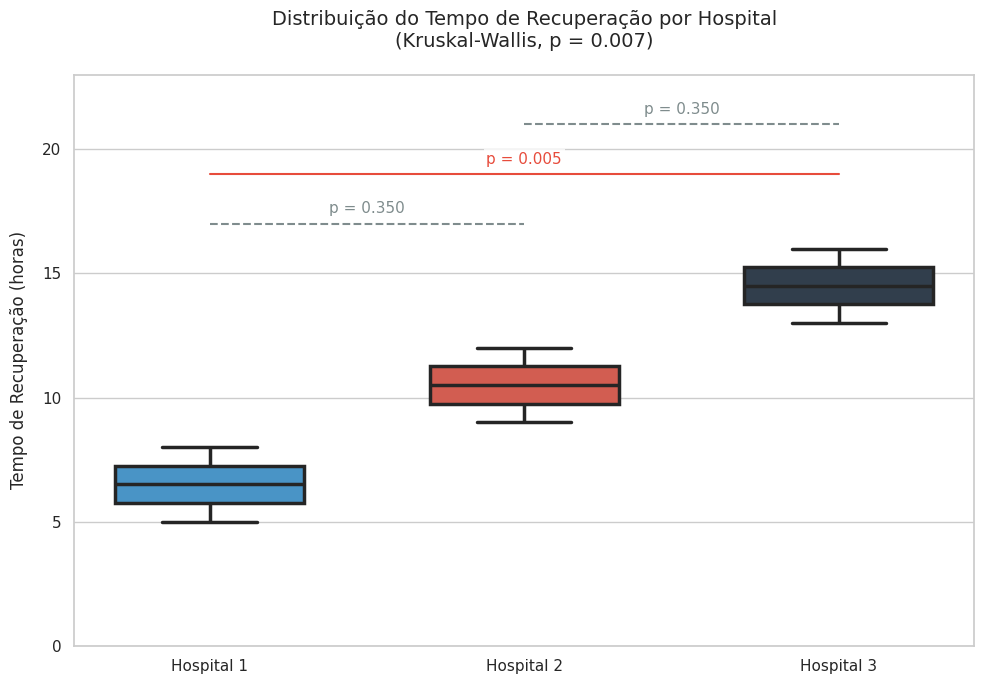

```python
import matplotlib.pyplot as plt
import seaborn as sns
import numpy as np
import pandas as pd
from scipy.stats import kruskal
import scikit_posthocs as sp
from matplotlib import rcParams

# Cria figura
plt.figure(figsize=(10, 7))

# Boxplot principal (sem pontos individuais)
ax = sns.boxplot(data=dados_long, x='Hospital', y='Tempo',
                palette=["#3498db", "#e74c3c", "#2c3e50"],
                width=0.6, linewidth=2.5)

# Configurações do eixo
plt.ylabel("Tempo de Recuperação (horas)", fontsize=12, labelpad=10)
plt.xlabel("")
plt.title(f"Distribuição do Tempo de Recuperação por Hospital\n(Kruskal-Wallis, p = {kw_p:.3f})",
          fontsize=14, pad=20)

# Adiciona as comparações
base_y = dados_long['Tempo'].max() + 1
positions = {hosp: i for i, hosp in enumerate(hospitais)}

# Lista de comparações em ordem desejada
comparacoes_ordenadas = [
    ('Hospital 1', 'Hospital 2', dunn_result.iloc[0,1], 0),
    ('Hospital 1', 'Hospital 3', dunn_result.iloc[0,2], 1),
    ('Hospital 2', 'Hospital 3', dunn_result.iloc[1,2], 2)
]

# Adiciona linhas de comparação
for g1, g2, p_val, offset in comparacoes_ordenadas:
    x1, x2 = positions[g1], positions[g2]
    y = base_y + (offset * 2)

    # Estilo baseado na significância
    line_color = '#e74c3c' if p_val < 0.05 else '#7f8c8d'
    line_style = '-' if p_val < 0.05 else '--'

    # Linha de conexão reta e nivelada
    plt.plot([x1, x2], [y, y],
             lw=1.5, c=line_color, linestyle=line_style)

    # Texto do p-valor centralizado
    p_text = f"p = {p_val:.3f}" if p_val >= 0.001 else "p < 0.001"
    plt.text((x1+x2)/2, y+0.3, p_text,
             ha='center', va='bottom',
             color=line_color,
             fontsize=11,
             bbox=dict(facecolor='white', alpha=0.8, edgecolor='none', pad=2))

# Ajustes finais
plt.ylim(0, base_y + 6)
plt.tight_layout()
plt.show()
```

## 🔍 Parte 2: Testes Não Paramétricos para Proporções

### 📌 Teste Qui-Quadrado (χ²)

- Quando usar? Comparar proporções em tabelas de contingência. O teste qui-quadrado de Pearson compara frequências observadas com frequências esperadas sob a hipótese nula (H₀) de independência entre variáveis categóricas.
- Exemplo: Verificar se há associação entre fumante (Sim/Não) e doença pulmonar (Sim/Não).

```python
from scipy.stats import chi2_contingency

# Tabela 2x2: [Fumantes com doença, Fumantes sem doença], [Não fumantes com doença, Não fumantes sem doença]
tabela = [[30, 70], [10, 90]]
```

```python
df_tabela = pd.DataFrame(tabela,
                         index=['Fumantes', 'Não Fumantes'],
                         columns=['Doença Pulmonar Sim', 'Doença Pulmonar Não'])
df_tabela
```

|  | Doença Pulmonar Sim | Doença Pulmonar Não |
| --- | --- | --- |
| Fumantes | 30 | 70 |
| Não Fumantes | 10 | 90 |

```python
fumante_com_doença = 30
fumante_sem_doença = 70
não_fumante_com_doença = 10
não_fumante_sem_doença = 90
```

#### Cálculo manual

**Calcule os valores esperados (se H₀ fosse verdadeira):**

```python
#Fumantes com doença
esperado_fumante_com_doença = (fumante_com_doença + fumante_sem_doença ) * ( fumante_com_doença + não_fumante_com_doença ) / (fumante_com_doença + não_fumante_com_doença + fumante_sem_doença + não_fumante_sem_doença)
esperado_fumante_com_doença
```

```
20.0
```

```python
#Fumantes saudáveis
esperado_fumante_sem_doença = (fumante_com_doença + fumante_sem_doença ) * ( fumante_sem_doença + não_fumante_sem_doença ) / (fumante_com_doença + não_fumante_com_doença + fumante_sem_doença + não_fumante_sem_doença)
esperado_fumante_sem_doença
```

```
80.0
```

```python
#Não-fumantes com doença
esperado_não_fumante_com_doença = (não_fumante_com_doença + não_fumante_sem_doença ) * ( fumante_com_doença + não_fumante_com_doença ) / (fumante_com_doença + não_fumante_com_doença + fumante_sem_doença + não_fumante_sem_doença)
esperado_não_fumante_com_doença
```

```
20.0
```

```python
esperado_não_fumante_sem_doença = (não_fumante_com_doença + não_fumante_sem_doença ) * ( fumante_sem_doença + não_fumante_sem_doença) / (fumante_com_doença + não_fumante_com_doença + fumante_sem_doença + não_fumante_sem_doença)
esperado_não_fumante_sem_doença
```

```
80.0
```

Sob a hipótese nula (H₀) de não associação entre fumo e doença:

- A proporção geral de doença é 40/200 = 20%
- Esperaríamos que 20% dos fumantes (20 de 100) e 20% dos não-fumantes (20 de 100) tivessem doença
- O mesmo raciocínio se aplica aos saudáveis (80 em cada grupo)

Comparando observado vs esperado:

- Fumantes com doença: 30 (observado) vs 20 (esperado) → +50% mais casos
- Não-fumantes com doença: 10 vs 20 → 50% menos casos
- Essas discrepâncias são o que o teste qui-quadrado avalia para determinar se a associação é estatisticamente significativa

**Calcule a estatística χ²:**

É uma distribuição teórica que: Descreve como varia a soma de quadrados de variáveis normais padrão, tem forma assimétrica à direita e depende dos graus de liberdade (gl)

```python
x2_1 = ((fumante_com_doença - esperado_fumante_com_doença)**2 / esperado_fumante_com_doença)
x2_2 = ((fumante_sem_doença - esperado_fumante_sem_doença)**2 / esperado_fumante_sem_doença)
x2_3 = ((não_fumante_com_doença - esperado_não_fumante_com_doença)**2 / esperado_não_fumante_com_doença)
x2_4 = ((não_fumante_sem_doença - esperado_não_fumante_sem_doença)**2 / esperado_não_fumante_sem_doença)
x2 = x2_1 + x2_2 + x2_3 + x2_4
print(x2)
```

```
12.5
```

```python
gl = (2 - 1) * (2 - 1)
print(f"Graus de Liberdade (gl) = {gl}")
```

```
Graus de Liberdade (gl) = 1
```

```python
from scipy.stats import chi2
p_valor = 1 - chi2.cdf(x2, df=gl)
p_valor
```

```
np.float64(0.00040695201744500586)
```

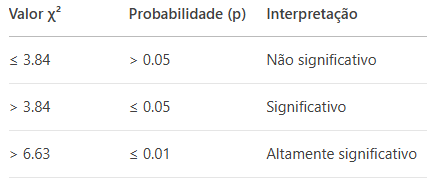

[figure not shown]

```python
import numpy as np
import matplotlib.pyplot as plt
from scipy.stats import chi2

# Cria a distribuição χ² com 1 gl
x = np.linspace(0, 15, 500)
y = chi2.pdf(x, df=1)

# Gráfico
plt.figure(figsize=(10,5))
plt.plot(x, y, 'b-', label='χ² (gl=1)')
plt.axvline(11.25, color='red', linestyle='--', label='Nosso χ² = 11.25')
plt.fill_between(x[x>=11.25], y[x>=11.25], color='red', alpha=0.3, label='p-valor')
plt.legend()
plt.title("Distribuição Qui-Quadrado com 1 Grau de Liberdade")
plt.xlabel("Valor χ²")
plt.ylabel("Densidade de Probabilidade")
plt.show()
```

#### Cálculo Automático

O código:

```python
chi2, p, dof, expected = chi2_contingency(tabela)
print(f"p-valor = {p:.4f}")  # p ≤ 0.05 → associação significativa
```

```
p-valor = 0.0008
```

```python
expected
```

```
array([[20., 80.],
       [20., 80.]])
```

📝 Interpretação:

- H₀: Não há associação entre as variáveis.
- p ≤ 0.05 → Rejeita H₀ (ex.: fumar está associado à doença).

### 📌 Teste exato de Fisher

- Quando usar? Use o teste exato de Fisher quando você deseja avaliar a associação entre duas variáveis categóricas em uma tabela 2x2 (duas linhas e duas colunas), especialmente quando os valores esperados são pequenos (menores que 5). Diferente do teste qui-quadrado, não depende de aproximações. É ideal para amostras pequenas.
- Exemplo: Vamos verificar se existe associação entre ser fumante e ter doença pulmonar com uma amostra pequena:

```python
import scipy.stats as stats
import pandas as pd

# tabela 2x2
# linha 1: fumantes, linha 2: não fumantes
# colunas: com doença, sem doença
tabela = [[5, 1], [2, 8]]
```

```python
df_tabela = pd.DataFrame(tabela,
                         index=['Fumantes', 'Não Fumantes'],
                         columns=['Doença Pulmonar Sim', 'Doença Pulmonar Não'])
df_tabela
```

|  | Doença Pulmonar Sim | Doença Pulmonar Não |
| --- | --- | --- |
| Fumantes | 5 | 1 |
| Não Fumantes | 2 | 8 |

O Teste de Fisher calcula todas as possíveis combinações de tabelas 2x2 com os mesmos totais marginais, assumindo que a hipótese nula (independência entre as variáveis) é verdadeira.

➡️ O p-valor obtido é a soma das probabilidades dessas tabelas tão extremas quanto ou mais do que a observada.

Por isso, é considerado exato, sem aproximações da distribuição qui-quadrado.

```python
oddsratio, p_valor = stats.fisher_exact(tabela)
print(f"p-valor = {p_valor:.4f}")
```

```
p-valor = 0.0350
```

📝 Interpretação:

- Se p ≤ 0,05, rejeita-se H₀ ➔ há associação significativa.
- Se p > 0,05, não se rejeita H₀ ➔ não há evidência de associação.

No exemplo, o p-valor indica que existe associação significativa entre ser fumante e ter doença pulmonar.